# Chapter 3: Linear Regression

```r
library(MASS)
library(ISLR2)
library(stargazer)
library(tidyverse)
library(ggthemes)
```

```r
# medv: median house value
# rm: average number of rooms per house
# age: age of house
# lstat: percentage of household with low socioeconomic status

head(Boston)
```

```
##      crim zn indus chas   nox    rm  age    dis rad tax ptratio lstat medv
## 1 0.00632 18  2.31    0 0.538 6.575 65.2 4.0900   1 296    15.3  4.98 24.0
## 2 0.02731  0  7.07    0 0.469 6.421 78.9 4.9671   2 242    17.8  9.14 21.6
## 3 0.02729  0  7.07    0 0.469 7.185 61.1 4.9671   2 242    17.8  4.03 34.7
## 4 0.03237  0  2.18    0 0.458 6.998 45.8 6.0622   3 222    18.7  2.94 33.4
## 5 0.06905  0  2.18    0 0.458 7.147 54.2 6.0622   3 222    18.7  5.33 36.2
## 6 0.02985  0  2.18    0 0.458 6.430 58.7 6.0622   3 222    18.7  5.21 28.7
```

`names(lm.fit)` will tell us what pieces of information is stored in lm.fit: * **coefficients** * **residuals** * **effects** * **rank** * **fitted.values** * **assign**  
* **qr** * **df.residual** * **xlevels** * **call** * **terms** * **model**

```r
lm.fit <- lm(medv ~ lstat, data = Boston)
summary(lm.fit)
```

```
##
## Call:
## lm(formula = medv ~ lstat, data = Boston)
##
## Residuals:
##     Min      1Q  Median      3Q     Max
## -15.168  -3.990  -1.318   2.034  24.500
##
## Coefficients:
##             Estimate Std. Error t value Pr(>|t|)
## (Intercept) 34.55384    0.56263   61.41   <2e-16 ***
## lstat       -0.95005    0.03873  -24.53   <2e-16 ***
## ---
## Signif. codes:  0 '***' 0.001 '**' 0.01 '*' 0.05 '.' 0.1 ' ' 1
##
## Residual standard error: 6.216 on 504 degrees of freedom
## Multiple R-squared:  0.5441, Adjusted R-squared:  0.5432
## F-statistic: 601.6 on 1 and 504 DF,  p-value: < 2.2e-16
```

**Coefficients**

To extract coefficients, we can use the `coef()` function:

```r
coef(lm.fit)
```

```
## (Intercept)       lstat
##  34.5538409  -0.9500494
```

**Confidence Interval**

```r
confint(lm.fit)
```

```
##                 2.5 %     97.5 %
## (Intercept) 33.448457 35.6592247
## lstat       -1.026148 -0.8739505
```

For instance, the 95 % confidence interval associated with a `lstat` value of 10 is (24.47, 25.63), and the 95 % prediction interval is (12.828, 37.28). As expected, the confidence and prediction intervals are centered around the same point (a predicted value of 25.05 for medv when `lstat` equals 10), but the latter are substantially wider.

```r
predict(lm.fit,
        data.frame(lstat = (c(5, 10, 15))),
        interval = "confidence")
```

```
##        fit      lwr      upr
## 1 29.80359 29.00741 30.59978
## 2 25.05335 24.47413 25.63256
## 3 20.30310 19.73159 20.87461
```

```r
predict(lm.fit,
        data.frame(lstat = (c(5, 10, 15))),
        interval = "prediction")
```

```
##        fit       lwr      upr
## 1 29.80359 17.565675 42.04151
## 2 25.05335 12.827626 37.27907
## 3 20.30310  8.077742 32.52846
```

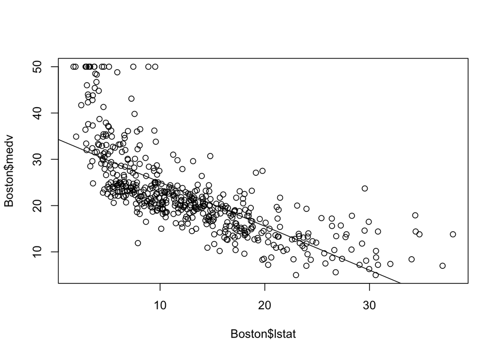

```r
plot(Boston$lstat, Boston$medv)
# Least-squared regression line
abline(lm.fit)
```

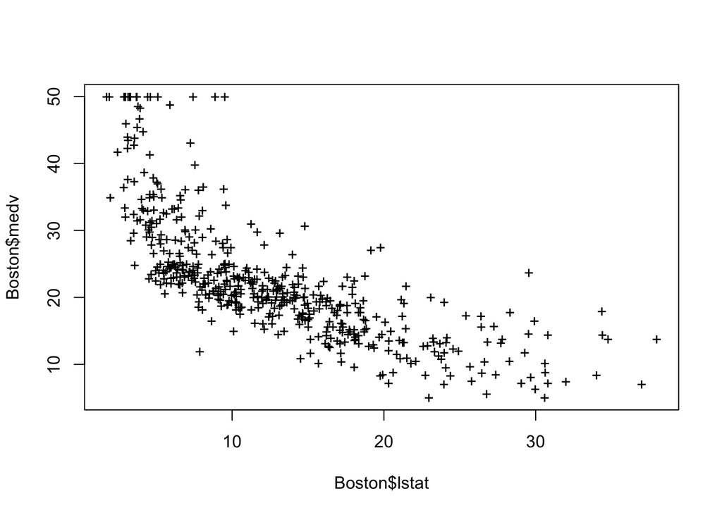

```r
# plot(Boston$lstat, Boston$medv)
# abline(lm.fit, lwd = 3)
# abline(lm.fit, lwd = 3, col = 'red')
# plot(Boston$lstat, Boston$medv, col = 'red')
# plot(Boston$lstat, Boston$medv, pch = 20)
plot(Boston$lstat, Boston$medv, pch = "+")
```

```r
# plot(1:20, 1:20, pch = 1:20)
```

`par(mfrow = c(2, 2))` divides the plotting region into a 2 × 2 grid of panels.

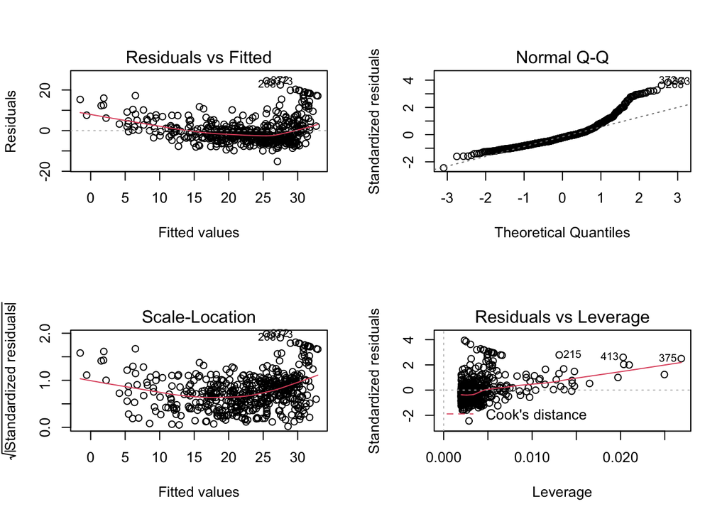

```r
par(mfrow = c(2, 2))
plot(lm.fit)
```

**Residuals and Outliers**

Another important assumption of the linear regression model is that the error terms have a constant variance. The standard errors, confidence intervals, and hypothesis tests associated with the linear model rely upon this assumption. Plotting the residuals against the predictions is a way to confirm this assumption.

- `residuals()`
- `rstudent()`: will return the studentized residuals. A studentized residual is the quotient resulting from the division of a residual by an estimate of its standard deviation. It is a form of a Student’s t-statistic, with the estimate of error varying between points.

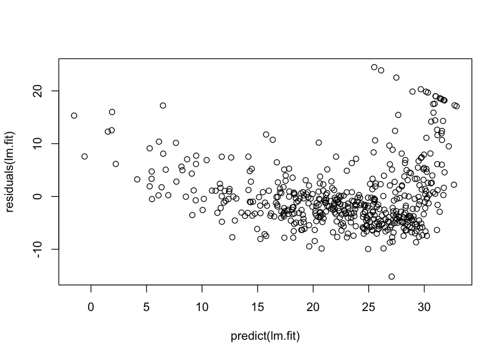

```r
plot(predict(lm.fit), residuals(lm.fit))
```

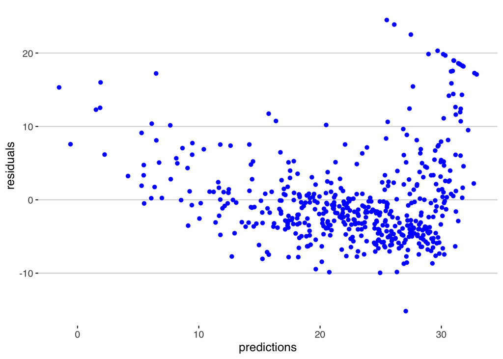

```r
tibble(predictions = predict(lm.fit), residuals = residuals(lm.fit)) %>%
  ggplot(aes(x = predictions, y = residuals)) +
  geom_point(col = 'blue') +
  theme_hc()
```

- Outliers are observations for which the response $y_i$ is unusual given the predictor $x_i$.
- Removing the outlier has little effect on the least squares line: it leads to almost no change in the slope, and a miniscule reduction in the intercept. It is typical for an outlier that does not have an unusual predictor value to have little effect on the least squares fit.
- Inclusion of the outliers may decrease goodness of fit (R-squared) and increase RSE.
- It can be difficult to decide how large a residual needs to be before we consider the point to be an outlier. To address this problem, instead of plotting the residuals, we can plot the studentized residuals, computed by dividing each residual by its estimated standard error. **Observations whose studentized residuals are greater than 3 in abso- lute value are possible outliers.**
- If we believe that an outlier has occurred due to an error in data collection or recording, then one solution is to simply remove the observation. However, care should be taken, since an outlier may instead indicate a deficiency with the model, such as a missing predictor.

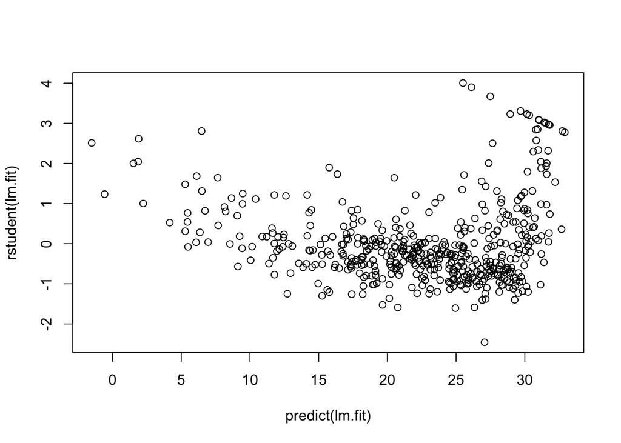

```r
plot(predict(lm.fit), rstudent(lm.fit))
```

**Leverage statistics**

On the basis of the residual plots, there is some evidence of non-linearity. Leverage statistics can be computed for any number of predictors using the `hatvalues()` function. The `which.max()` function identifies the index of the largest element of a vector. In this case, it tells us which observation has the largest leverage statistic.

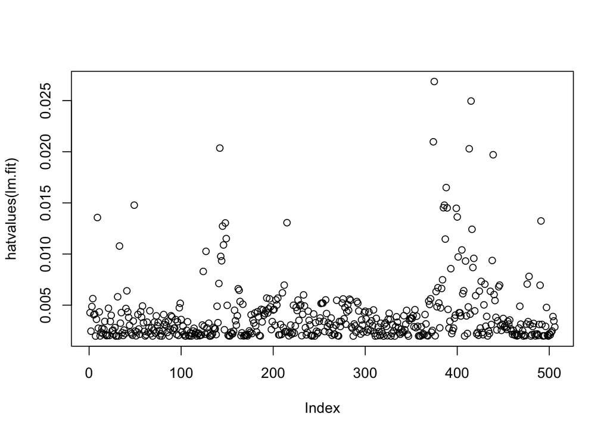

```r
plot(hatvalues(lm.fit))
```

```r
which.max(hatvalues(lm.fit))
```

```
## 375
## 375
```